# Ce notebook est organisé comme suivant:

## Jointure des dataframes

Puis, je fais la jointure des dataframes afin d'avoir une dataframe qui regroupe toutes les colonnes des données.

```python
# Recherche de valeurs différentes pour la colonne client_id entre deux dataframes - transactions et clients
# Pas de valeurs différentes trouvées

diff_client_id = list(set(transactions.client_id.unique()
                       ).difference(clients.client_id.unique()))
diff_client_id
```

```
[]
```

```python
# Jointure des dataframes - transactions et clients, nommé df

df = pd.merge(transactions, clients,how='left', on='client_id')
df
```

|  | id_prod | date | session_id | client_id | sex | birth |
| --- | --- | --- | --- | --- | --- | --- |
| 0 | 0_1518 | 2022-05-20 13:21:29.043970 | s_211425 | c_103 | f | 1986 |
| 1 | 1_251 | 2022-02-02 07:55:19.149409 | s_158752 | c_8534 | m | 1988 |
| 2 | 0_1277 | 2022-06-18 15:44:33.155329 | s_225667 | c_6714 | f | 1968 |
| 3 | 2_209 | 2021-06-24 04:19:29.835891 | s_52962 | c_6941 | m | 2000 |
| 4 | 0_1509 | 2023-01-11 08:22:08.194479 | s_325227 | c_4232 | m | 1980 |
| ... | ... | ... | ... | ... | ... | ... |
| 679527 | 0_1551 | 2022-01-15 13:05:06.246925 | s_150195 | c_8489 | f | 1951 |
| 679528 | 1_639 | 2022-03-19 16:03:23.429229 | s_181434 | c_4370 | f | 1977 |
| 679529 | 0_1425 | 2022-12-20 04:33:37.584749 | s_314704 | c_304 | f | 1988 |
| 679530 | 0_1994 | 2021-07-16 20:36:35.350579 | s_63204 | c_2227 | m | 1986 |
| 679531 | 1_523 | 2022-09-28 01:12:01.973763 | s_274568 | c_3873 | m | 1995 |

679532 rows × 6 columns

```python
# Recherche de valeurs différentes pour la colonne id_prod entre deux dataframes - df et produits
# une valeur différente trouvée

diff_id_prod = list(set(df.id_prod.unique()
                       ).difference(produits.id_prod.unique()))
diff_id_prod
```

```
['0_2245']
```

```python
# Jointure des dataframes - df et produits, nommé df1

df1 = pd.merge(df, produits,how='left', on='id_prod')
df1
```

|  | id_prod | date | session_id | client_id | sex | birth | price | categ |
| --- | --- | --- | --- | --- | --- | --- | --- | --- |
| 0 | 0_1518 | 2022-05-20 13:21:29.043970 | s_211425 | c_103 | f | 1986 | 4.18 | 0.0 |
| 1 | 1_251 | 2022-02-02 07:55:19.149409 | s_158752 | c_8534 | m | 1988 | 15.99 | 1.0 |
| 2 | 0_1277 | 2022-06-18 15:44:33.155329 | s_225667 | c_6714 | f | 1968 | 7.99 | 0.0 |
| 3 | 2_209 | 2021-06-24 04:19:29.835891 | s_52962 | c_6941 | m | 2000 | 69.99 | 2.0 |
| 4 | 0_1509 | 2023-01-11 08:22:08.194479 | s_325227 | c_4232 | m | 1980 | 4.99 | 0.0 |
| ... | ... | ... | ... | ... | ... | ... | ... | ... |
| 679527 | 0_1551 | 2022-01-15 13:05:06.246925 | s_150195 | c_8489 | f | 1951 | 12.99 | 0.0 |
| 679528 | 1_639 | 2022-03-19 16:03:23.429229 | s_181434 | c_4370 | f | 1977 | 10.99 | 1.0 |
| 679529 | 0_1425 | 2022-12-20 04:33:37.584749 | s_314704 | c_304 | f | 1988 | 12.99 | 0.0 |
| 679530 | 0_1994 | 2021-07-16 20:36:35.350579 | s_63204 | c_2227 | m | 1986 | 4.98 | 0.0 |
| 679531 | 1_523 | 2022-09-28 01:12:01.973763 | s_274568 | c_3873 | m | 1995 | 23.99 | 1.0 |

679532 rows × 8 columns

```python
# Vérification des données, s'il y a des valeurs manquantes

df1.info()
```

```
<class 'pandas.core.frame.DataFrame'>
Int64Index: 679532 entries, 0 to 679531
Data columns (total 8 columns):
 #   Column      Non-Null Count   Dtype
---  ------      --------------   -----
 0   id_prod     679532 non-null  object
 1   date        679532 non-null  object
 2   session_id  679532 non-null  object
 3   client_id   679532 non-null  object
 4   sex         679532 non-null  object
 5   birth       679532 non-null  int64
 6   price       679311 non-null  float64
 7   categ       679311 non-null  float64
dtypes: float64(2), int64(1), object(5)
memory usage: 46.7+ MB
```

## Nettoyage des données

Afin d’obtenir un jeu de données exploitable, je vérifie les anomalies qui peuvent fausser les analyses. Je trouve deux anomalies comme suivant:

- Anomalie concernant les clients de test

  Il s'agit des tests, ce ne sont pas les produits que la librairie a vendus, inutile pour l'analyse.
- Anomalie concernant le produit de la référence 0_2245

  Il s'agit d'un produit de la catégorie 0 que la librairie a vendu, mais il manque du prix unitaire, après vérifier la variance, qui est égale 24, je trouve que c'est grand, c'est mieux de ne pas imposer par le prix moyen de cette catégorie.

Donc, je décide de supprimer les données de ces deux anomalies.

### Anomalie - clients de test

```python
# Anomalie détectée pour id_prod = 'T_0', il s'agit des tests

cherche1 = df1[df1['id_prod'] == 'T_0']
cherche1
```

|  | id_prod | date | session_id | client_id | sex | birth | price | categ |
| --- | --- | --- | --- | --- | --- | --- | --- | --- |
| 3019 | T_0 | test_2021-03-01 02:30:02.237419 | s_0 | ct_0 | f | 2001 | -1.0 | 0.0 |
| 5138 | T_0 | test_2021-03-01 02:30:02.237425 | s_0 | ct_0 | f | 2001 | -1.0 | 0.0 |
| 9668 | T_0 | test_2021-03-01 02:30:02.237437 | s_0 | ct_1 | m | 2001 | -1.0 | 0.0 |
| 10728 | T_0 | test_2021-03-01 02:30:02.237436 | s_0 | ct_0 | f | 2001 | -1.0 | 0.0 |
| 15292 | T_0 | test_2021-03-01 02:30:02.237430 | s_0 | ct_0 | f | 2001 | -1.0 | 0.0 |
| ... | ... | ... | ... | ... | ... | ... | ... | ... |
| 657830 | T_0 | test_2021-03-01 02:30:02.237417 | s_0 | ct_0 | f | 2001 | -1.0 | 0.0 |
| 662081 | T_0 | test_2021-03-01 02:30:02.237427 | s_0 | ct_1 | m | 2001 | -1.0 | 0.0 |
| 670680 | T_0 | test_2021-03-01 02:30:02.237449 | s_0 | ct_1 | m | 2001 | -1.0 | 0.0 |
| 671647 | T_0 | test_2021-03-01 02:30:02.237424 | s_0 | ct_1 | m | 2001 | -1.0 | 0.0 |
| 679180 | T_0 | test_2021-03-01 02:30:02.237425 | s_0 | ct_1 | m | 2001 | -1.0 | 0.0 |

200 rows × 8 columns

```python
# Vérification s'il y a de fause transaction réalisée et mal enregistrée par ces deux clients de test
# Il y en a pas, car le nombre de ligne est toujours de 200

test = df1[(df1['client_id'] == 'ct_0') | (df1['client_id'] == 'ct_1')]
test
```

|  | id_prod | date | session_id | client_id | sex | birth | price | categ |
| --- | --- | --- | --- | --- | --- | --- | --- | --- |
| 3019 | T_0 | test_2021-03-01 02:30:02.237419 | s_0 | ct_0 | f | 2001 | -1.0 | 0.0 |
| 5138 | T_0 | test_2021-03-01 02:30:02.237425 | s_0 | ct_0 | f | 2001 | -1.0 | 0.0 |
| 9668 | T_0 | test_2021-03-01 02:30:02.237437 | s_0 | ct_1 | m | 2001 | -1.0 | 0.0 |
| 10728 | T_0 | test_2021-03-01 02:30:02.237436 | s_0 | ct_0 | f | 2001 | -1.0 | 0.0 |
| 15292 | T_0 | test_2021-03-01 02:30:02.237430 | s_0 | ct_0 | f | 2001 | -1.0 | 0.0 |
| ... | ... | ... | ... | ... | ... | ... | ... | ... |
| 657830 | T_0 | test_2021-03-01 02:30:02.237417 | s_0 | ct_0 | f | 2001 | -1.0 | 0.0 |
| 662081 | T_0 | test_2021-03-01 02:30:02.237427 | s_0 | ct_1 | m | 2001 | -1.0 | 0.0 |
| 670680 | T_0 | test_2021-03-01 02:30:02.237449 | s_0 | ct_1 | m | 2001 | -1.0 | 0.0 |
| 671647 | T_0 | test_2021-03-01 02:30:02.237424 | s_0 | ct_1 | m | 2001 | -1.0 | 0.0 |
| 679180 | T_0 | test_2021-03-01 02:30:02.237425 | s_0 | ct_1 | m | 2001 | -1.0 | 0.0 |

200 rows × 8 columns

```python
# Transformation de la colonne date au format datetime

df1['date'] = pd.to_datetime(df1['date'], errors='coerce')
```

```python
df1.info()
```

```
<class 'pandas.core.frame.DataFrame'>
Int64Index: 679532 entries, 0 to 679531
Data columns (total 8 columns):
 #   Column      Non-Null Count   Dtype
---  ------      --------------   -----
 0   id_prod     679532 non-null  object
 1   date        679332 non-null  datetime64[ns]
 2   session_id  679532 non-null  object
 3   client_id   679532 non-null  object
 4   sex         679532 non-null  object
 5   birth       679532 non-null  int64
 6   price       679311 non-null  float64
 7   categ       679311 non-null  float64
dtypes: datetime64[ns](1), float64(2), int64(1), object(4)
memory usage: 46.7+ MB
```

```python
# Revérification pour la référence 'T_0'
# La colonne date pour cette réf est bien transformet en NaT

cherche2 = df1[df1['id_prod'] == 'T_0']
cherche2
```

|  | id_prod | date | session_id | client_id | sex | birth | price | categ |
| --- | --- | --- | --- | --- | --- | --- | --- | --- |
| 3019 | T_0 | NaT | s_0 | ct_0 | f | 2001 | -1.0 | 0.0 |
| 5138 | T_0 | NaT | s_0 | ct_0 | f | 2001 | -1.0 | 0.0 |
| 9668 | T_0 | NaT | s_0 | ct_1 | m | 2001 | -1.0 | 0.0 |
| 10728 | T_0 | NaT | s_0 | ct_0 | f | 2001 | -1.0 | 0.0 |
| 15292 | T_0 | NaT | s_0 | ct_0 | f | 2001 | -1.0 | 0.0 |
| ... | ... | ... | ... | ... | ... | ... | ... | ... |
| 657830 | T_0 | NaT | s_0 | ct_0 | f | 2001 | -1.0 | 0.0 |
| 662081 | T_0 | NaT | s_0 | ct_1 | m | 2001 | -1.0 | 0.0 |
| 670680 | T_0 | NaT | s_0 | ct_1 | m | 2001 | -1.0 | 0.0 |
| 671647 | T_0 | NaT | s_0 | ct_1 | m | 2001 | -1.0 | 0.0 |
| 679180 | T_0 | NaT | s_0 | ct_1 | m | 2001 | -1.0 | 0.0 |

200 rows × 8 columns

### Anomalie - produit référence 0_2245

```python
# Recherche des valeurs manquantes qui correspond à la différence que l'on a trouvé précedent, ref '0_2245'
# id_prod commence par 0, il s'agit de la catégorie 0

cherche3 = df1[df1['id_prod'] == '0_2245']
cherche3
```

|  | id_prod | date | session_id | client_id | sex | birth | price | categ |
| --- | --- | --- | --- | --- | --- | --- | --- | --- |
| 2633 | 0_2245 | 2022-09-23 07:22:38.636773 | s_272266 | c_4746 | m | 1940 | NaN | NaN |
| 10106 | 0_2245 | 2022-07-23 09:24:14.133889 | s_242482 | c_6713 | f | 1963 | NaN | NaN |
| 11727 | 0_2245 | 2022-12-03 03:26:35.696673 | s_306338 | c_5108 | m | 1978 | NaN | NaN |
| 15675 | 0_2245 | 2021-08-16 11:33:25.481411 | s_76493 | c_1391 | m | 1991 | NaN | NaN |
| 16377 | 0_2245 | 2022-07-16 05:53:01.627491 | s_239078 | c_7954 | m | 1973 | NaN | NaN |
| ... | ... | ... | ... | ... | ... | ... | ... | ... |
| 669730 | 0_2245 | 2021-08-25 09:06:03.504061 | s_80395 | c_131 | m | 1981 | NaN | NaN |
| 670682 | 0_2245 | 2022-03-06 19:59:19.462288 | s_175311 | c_4167 | f | 1979 | NaN | NaN |
| 671286 | 0_2245 | 2022-05-16 11:35:20.319501 | s_209381 | c_4453 | m | 1981 | NaN | NaN |
| 675679 | 0_2245 | 2022-02-11 09:05:43.952857 | s_163405 | c_1098 | m | 1986 | NaN | NaN |
| 677996 | 0_2245 | 2021-12-14 22:34:54.589921 | s_134446 | c_4854 | m | 1968 | NaN | NaN |

221 rows × 8 columns

```python
# Calcul de la variance
# Si la variance n'est pas énorme, la solution pour nettoyer cette anomalie sera de l'imputation par la moyenne
# Dans notre cas, 24.39 pour la catégorie 0 pour un livre, je trouve que c'est beaucoup

df1.groupby('categ').var()['price']
```

```
categ
0.0      24.393121
1.0      57.530610
2.0    1579.984161
Name: price, dtype: float64
```

### Solution - suppression

```python
# Nettoyage des données, solution choisie : supprimer

data_propre = df1.dropna(how="any").reset_index(drop=True)
data_propre
```

|  | id_prod | date | session_id | client_id | sex | birth | price | categ |
| --- | --- | --- | --- | --- | --- | --- | --- | --- |
| 0 | 0_1518 | 2022-05-20 13:21:29.043970 | s_211425 | c_103 | f | 1986 | 4.18 | 0.0 |
| 1 | 1_251 | 2022-02-02 07:55:19.149409 | s_158752 | c_8534 | m | 1988 | 15.99 | 1.0 |
| 2 | 0_1277 | 2022-06-18 15:44:33.155329 | s_225667 | c_6714 | f | 1968 | 7.99 | 0.0 |
| 3 | 2_209 | 2021-06-24 04:19:29.835891 | s_52962 | c_6941 | m | 2000 | 69.99 | 2.0 |
| 4 | 0_1509 | 2023-01-11 08:22:08.194479 | s_325227 | c_4232 | m | 1980 | 4.99 | 0.0 |
| ... | ... | ... | ... | ... | ... | ... | ... | ... |
| 679106 | 0_1551 | 2022-01-15 13:05:06.246925 | s_150195 | c_8489 | f | 1951 | 12.99 | 0.0 |
| 679107 | 1_639 | 2022-03-19 16:03:23.429229 | s_181434 | c_4370 | f | 1977 | 10.99 | 1.0 |
| 679108 | 0_1425 | 2022-12-20 04:33:37.584749 | s_314704 | c_304 | f | 1988 | 12.99 | 0.0 |
| 679109 | 0_1994 | 2021-07-16 20:36:35.350579 | s_63204 | c_2227 | m | 1986 | 4.98 | 0.0 |
| 679110 | 1_523 | 2022-09-28 01:12:01.973763 | s_274568 | c_3873 | m | 1995 | 23.99 | 1.0 |

679111 rows × 8 columns

À ce stade, nous avons un jeu de données exploitable, nous pouvons commencer notre calcul et analyse.

# Calcul du CA, différents indicateurs et analyse dans le temps

```python
# Calcul de la période étudiée

data_propre['date'].max(), data_propre['date'].min()
```

```
(Timestamp('2023-02-28 23:58:30.792755'),
 Timestamp('2021-03-01 00:01:07.843138'))
```

```python
# Donc, c'est sur une période de deux ans

data_propre['date'].max()-data_propre['date'].min()
```

```
Timedelta('729 days 23:57:22.949617')
```

## Calcul du CA total et du nombre total de vente

```python
# Calcul du CA total

data_propre['price'].sum()
```

```
11853728.68
```

```python
# Calcul du nombre total de vente

data_propre['session_id'].count()
```

```
679111
```

## Évolution du CA total dans le temps

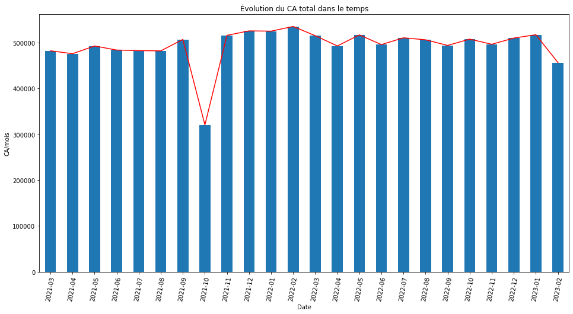

```python
# Évolution du CA total dans le temps

fig, axs = plt.subplots(figsize=(16, 8))
data_propre.groupby(data_propre['date'].dt.strftime(
    '%Y-%m'))['price'].sum().plot(kind='bar')
data_propre.groupby(data_propre['date'].dt.strftime(
    '%Y-%m'))['price'].sum().plot(color='r', linestyle='-')
plt.xticks(rotation=80)
plt.xlabel('Date')
plt.ylabel('CA/mois')
plt.title('Évolution du CA total dans le temps')
plt.show()
```

La librairie a réalisé un CA total à peu près de 11.8 millions euros en ligne pendant ces deux ans d'exercice, avec environ 680 milles livre vendu sans compter la référence 0_2245. La vente mensuelle est plutôt constante autour de 500 milles euro par mois. À part une diminution dramatique en octobre 2021 et un petit abaissement en février 2023.

## Calcul du CA, du nombre de vente et de la prix moyen par catégorie

```python
# Calcul du CA par catégorie

pd.set_option('display.float_format', lambda x: '%0.2f' % x)
data_propre.groupby('categ').sum()['price']
```

```
categ
0.00   4419730.97
1.00   4653722.69
2.00   2780275.02
Name: price, dtype: float64
```

```python
# Calcul du nombre de vente par catégorie

data_propre['categ'].value_counts()
```

```
0.00    415459
1.00    227169
2.00     36483
Name: categ, dtype: int64
```

```python
# Calcul de la moyenne du prix de vente par catégorie

data_propre.groupby('categ').mean()['price']
```

```
categ
0.00   10.64
1.00   20.49
2.00   76.21
Name: price, dtype: float64
```

## Évolution du CA et du nombre de vente par catégorie dans le temps

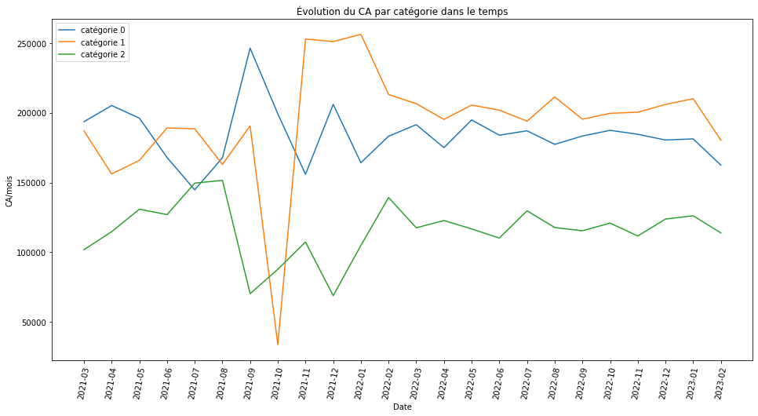

```python
# Évolution du CA par catégorie dans le temps

fig, axs = plt.subplots(figsize=(16, 8))
plt.plot(data_propre[data_propre['categ'] == 0.00].groupby(
    data_propre['date'].dt.strftime('%Y-%m'))['price'].sum(), label='catégorie 0')
plt.plot(data_propre[data_propre['categ'] == 1.00].groupby(
    data_propre['date'].dt.strftime('%Y-%m'))['price'].sum(), label='catégorie 1')
plt.plot(data_propre[data_propre['categ'] == 2.00].groupby(
    data_propre['date'].dt.strftime('%Y-%m'))['price'].sum(), label='catégorie 2')
plt.xticks(rotation=80)
plt.xlabel('Date')
plt.ylabel('CA/mois')
plt.title('Évolution du CA par catégorie dans le temps')
plt.legend(loc='upper left')
plt.show()
```

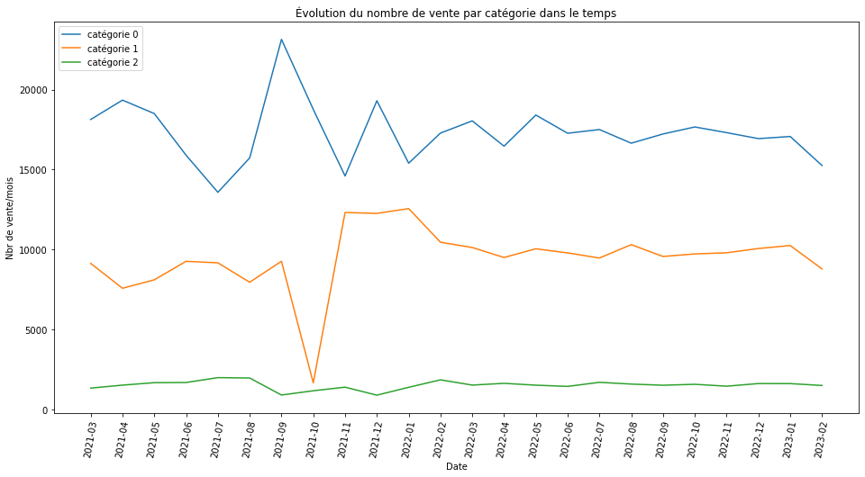

```python
# Évolution du nombre de vente par catégorie dans le temps

fig, axs = plt.subplots(figsize=(16, 8))
plt.plot(data_propre[data_propre['categ'] == 0.00].groupby(
    data_propre['date'].dt.strftime('%Y-%m'))['session_id'].count(), label='catégorie 0')
plt.plot(data_propre[data_propre['categ'] == 1.00].groupby(
    data_propre['date'].dt.strftime('%Y-%m'))['session_id'].count(), label='catégorie 1')
plt.plot(data_propre[data_propre['categ'] == 2.00].groupby(
    data_propre['date'].dt.strftime('%Y-%m'))['session_id'].count(), label='catégorie 2')
plt.xticks(rotation=80)
plt.xlabel('Date')
plt.ylabel('Nbr de vente/mois')
plt.title('Évolution du nombre de vente par catégorie dans le temps')
plt.legend(loc='upper left')
plt.show()
```

Cependant, quand on regarde le nombre de vente par catégorie, les produits de la catégorie 0 sont mieux vendu, qui est à peu près 2 fois plus par rapport à la catégorie 1. Au contraire, le prix moyen de la catégorie 1 est 2 fois plus cher que celui de la catégorie 0, par quoi s'explique pourquoi la catégorie génère plus de CA. Le prix moyen de la catégorie 2 est beaucoup plus cher, qui est de 76 euros, c'est pourquoi ils ont le moins de vente.

## Zoom sur la vente de février 2023

On vérifie pourquoi il y a une petite baisse en février 2023. Donc, je crée une dataframe qui regroupe toutes les données de février 2023. En comparant avec l'évolution de vente par catégorie en février 2022, la vente de catégorie 0 et 1 semble diminuée. Comme on n’a pas d'autre information, je ne peux pas analyser plus profond, cela peut être causé par l'efficacité de marketing ou bien autres raisons, on doit vérifier.

```python
# Zoom sur la vente d'octobre 2021

vente_fev2023 = data_propre.loc[data_propre['date'].dt.strftime(
    '%Y-%m') == '2023-02'].reset_index(drop=True)
vente_fev2023
```

|  | id_prod | date | session_id | client_id | sex | birth | price | categ |
| --- | --- | --- | --- | --- | --- | --- | --- | --- |
| 0 | 1_466 | 2023-02-12 01:56:43.209032 | s_340314 | c_683 | f | 1958 | 15.81 | 1.00 |
| 1 | 0_1100 | 2023-02-04 21:47:33.892196 | s_336957 | c_3371 | f | 1945 | 3.03 | 0.00 |
| 2 | 0_1070 | 2023-02-26 18:54:47.189819 | s_347326 | c_252 | f | 1973 | 4.38 | 0.00 |
| 3 | 1_451 | 2023-02-01 23:52:14.086648 | s_335638 | c_2589 | f | 2004 | 20.99 | 1.00 |
| 4 | 0_1799 | 2023-02-24 12:37:57.830006 | s_346260 | c_2963 | f | 1957 | 9.99 | 0.00 |
| ... | ... | ... | ... | ... | ... | ... | ... | ... |
| 25540 | 0_1501 | 2023-02-13 01:52:47.117015 | s_340810 | c_7088 | m | 1987 | 11.99 | 0.00 |
| 25541 | 0_2028 | 2023-02-19 06:35:58.534247 | s_343763 | c_3005 | f | 1972 | 13.37 | 0.00 |
| 25542 | 0_1007 | 2023-02-12 04:58:42.744304 | s_340373 | c_3091 | m | 1977 | 4.99 | 0.00 |
| 25543 | 0_239 | 2023-02-23 19:41:31.080214 | s_345908 | c_7212 | f | 1975 | 8.99 | 0.00 |
| 25544 | 1_283 | 2023-02-21 12:38:21.739964 | s_344826 | c_8186 | m | 1978 | 14.99 | 1.00 |

25545 rows × 8 columns

### Évolution du nombre de vente par catégorie en février 2023

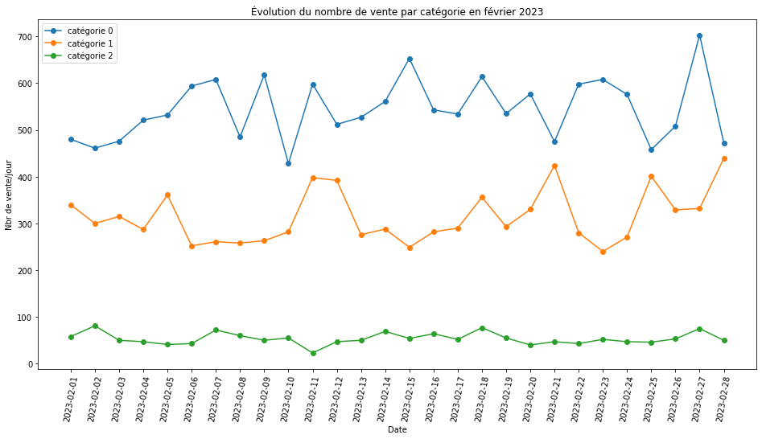

```python
# Évolution du nombre de vente par catégorie en février 2023

fig, axs = plt.subplots(figsize=(16, 8))
plt.plot(vente_fev2023[vente_fev2023['categ'] == 0.00].groupby(vente_fev2023['date'].dt.strftime(
    '%Y-%m-%d'))['session_id'].count(), label='catégorie 0', marker='o', linestyle='-')
plt.plot(vente_fev2023[vente_fev2023['categ'] == 1.00].groupby(vente_fev2023['date'].dt.strftime(
    '%Y-%m-%d'))['session_id'].count(), label='catégorie 1', marker='o', linestyle='-')
plt.plot(vente_fev2023[vente_fev2023['categ'] == 2.00].groupby(vente_fev2023['date'].dt.strftime(
    '%Y-%m-%d'))['session_id'].count(), label='catégorie 2', marker='o', linestyle='-')
plt.xticks(rotation=80)
plt.xlabel('Date')
plt.ylabel('Nbr de vente/jour')
plt.title('Évolution du nombre de vente par catégorie en février 2023')
plt.legend(loc='upper left')
plt.show()
```

```python
# On compare avec l'évolution du nombre de vente par catégorie en février 2022

vente_fev2022 = data_propre.loc[data_propre['date'].dt.strftime(
    '%Y-%m') == '2022-02'].reset_index(drop=True)
vente_fev2022
```

|  | id_prod | date | session_id | client_id | sex | birth | price | categ |
| --- | --- | --- | --- | --- | --- | --- | --- | --- |
| 0 | 1_251 | 2022-02-02 07:55:19.149409 | s_158752 | c_8534 | m | 1988 | 15.99 | 1.00 |
| 1 | 0_1060 | 2022-02-28 12:56:07.485622 | s_172187 | c_7672 | m | 1991 | 12.53 | 0.00 |
| 2 | 0_1376 | 2022-02-03 02:02:24.256156 | s_159145 | c_7778 | m | 1958 | 16.24 | 0.00 |
| 3 | 0_1323 | 2022-02-07 21:43:37.873616 | s_161607 | c_8535 | f | 1985 | 10.99 | 0.00 |
| 4 | 1_580 | 2022-02-07 09:38:14.883180 | s_161317 | c_5560 | m | 1986 | 21.09 | 1.00 |
| ... | ... | ... | ... | ... | ... | ... | ... | ... |
| 29589 | 0_336 | 2022-02-02 19:04:57.788464 | s_158995 | c_3730 | f | 1984 | 3.23 | 0.00 |
| 29590 | 0_2084 | 2022-02-06 03:14:30.276685 | s_160651 | c_6960 | f | 1986 | 10.80 | 0.00 |
| 29591 | 0_1316 | 2022-02-13 10:47:06.003991 | s_164479 | c_3206 | m | 1959 | 7.20 | 0.00 |
| 29592 | 0_1175 | 2022-02-05 12:27:38.661112 | s_160340 | c_2611 | f | 1987 | 8.99 | 0.00 |
| 29593 | 1_107 | 2022-02-09 00:43:04.839774 | s_162189 | c_5213 | m | 1999 | 10.99 | 1.00 |

29594 rows × 8 columns

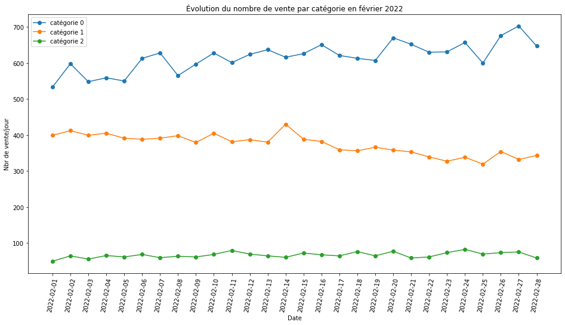

```python
# Évolution du nombre de vente par catégorie en février 2022

fig, axs = plt.subplots(figsize=(16, 8))
plt.plot(vente_fev2022[vente_fev2022['categ'] == 0.00].groupby(vente_fev2022['date'].dt.strftime(
    '%Y-%m-%d'))['session_id'].count(), label='catégorie 0', marker='o', linestyle='-')
plt.plot(vente_fev2022[vente_fev2022['categ'] == 1.00].groupby(vente_fev2022['date'].dt.strftime(
    '%Y-%m-%d'))['session_id'].count(), label='catégorie 1', marker='o', linestyle='-')
plt.plot(vente_fev2022[vente_fev2022['categ'] == 2.00].groupby(vente_fev2022['date'].dt.strftime(
    '%Y-%m-%d'))['session_id'].count(), label='catégorie 2', marker='o', linestyle='-')
plt.xticks(rotation=80)
plt.xlabel('Date')
plt.ylabel('Nbr de vente/jour')
plt.title('Évolution du nombre de vente par catégorie en février 2022')
plt.legend(loc='upper left')
plt.show()
```

## Zoom sur la vente d'octobre 2021

On vérifie pourquoi il y a une baisse importante en octobre 2021. Donc, je crée une dataframe qui regroupe toutes les données d'octobre 2021.

```python
# Zoom sur la vente d'octobre 2021

vente_oct2021 = data_propre.loc[data_propre['date'].dt.strftime(
    '%Y-%m') == '2021-10'].reset_index(drop=True)
vente_oct2021
```

|  | id_prod | date | session_id | client_id | sex | birth | price | categ |
| --- | --- | --- | --- | --- | --- | --- | --- | --- |
| 0 | 0_1409 | 2021-10-02 17:39:26.919537 | s_99013 | c_5725 | m | 1975 | 4.99 | 0.00 |
| 1 | 0_1247 | 2021-10-03 16:05:12.544172 | s_99443 | c_3394 | f | 1978 | 15.99 | 0.00 |
| 2 | 0_1272 | 2021-10-13 14:35:01.163737 | s_104207 | c_8534 | m | 1988 | 17.01 | 0.00 |
| 3 | 0_1102 | 2021-10-24 13:25:39.888945 | s_109442 | c_1609 | m | 1980 | 4.63 | 0.00 |
| 4 | 0_1079 | 2021-10-05 21:57:27.673800 | s_100557 | c_7918 | m | 1987 | 5.99 | 0.00 |
| ... | ... | ... | ... | ... | ... | ... | ... | ... |
| 21594 | 0_1418 | 2021-10-22 01:12:51.848429 | s_108264 | c_7213 | m | 1979 | 8.57 | 0.00 |
| 21595 | 0_1391 | 2021-10-26 04:40:29.252116 | s_110243 | c_7878 | m | 1989 | 7.99 | 0.00 |
| 21596 | 0_1609 | 2021-10-15 16:58:58.818380 | s_105230 | c_6714 | f | 1968 | 18.99 | 0.00 |
| 21597 | 0_1635 | 2021-10-01 23:19:52.888190 | s_98649 | c_1061 | m | 1991 | 16.99 | 0.00 |
| 21598 | 0_1572 | 2021-10-08 07:55:52.347300 | s_101701 | c_725 | f | 1964 | 8.61 | 0.00 |

21599 rows × 8 columns

### Évolution du nombre de vente par catégorie en octobre 2021

```python
# Calcul du CA total et nombre de vente total par catégorie en octobre 2021

vente_oct2021.groupby('categ')['price'].agg(['count','sum'])
```

| categ | count | sum |
| --- | --- | --- |
| 0.00 | 18762 | 199250.83 |
| 1.00 | 1666 | 33762.32 |
| 2.00 | 1171 | 87785.59 |

En effet, la chute commence le 2 octobre, et continue jusqu'au 27 octobre. La graphique et le calcul nous indique qu'il n'y a pas de vente pour la catégorie 1, cela peut-être à cause de la rupture de stock, ou bien mal enregistré des données, il faut vérifier. Comme on a vu précédemment, la vente moyenne de la catégorie 1 est à peu près de 200 milles par mois, on a ici environ 200 milles de moins par rapport au CA total pour cette période étudiée.

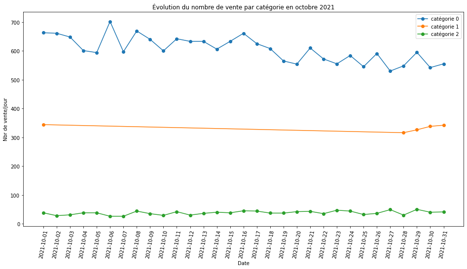

```python
# Évolution du nombre de vente par catégorie en octobre 2021

fig, axs = plt.subplots(figsize=(16, 8))
plt.plot(vente_oct2021[vente_oct2021['categ'] == 0.00].groupby(vente_oct2021['date'].dt.strftime(
    '%Y-%m-%d'))['session_id'].count(), label='catégorie 0', marker='o', linestyle='-')
plt.plot(vente_oct2021[vente_oct2021['categ'] == 1.00].groupby(vente_oct2021['date'].dt.strftime(
    '%Y-%m-%d'))['session_id'].count(), label='catégorie 1', marker='o', linestyle='-')
plt.plot(vente_oct2021[vente_oct2021['categ'] == 2.00].groupby(vente_oct2021['date'].dt.strftime(
    '%Y-%m-%d'))['session_id'].count(), label='catégorie 2', marker='o', linestyle='-')
plt.xticks(rotation=80)
plt.xlabel('Date')
plt.ylabel('Nbr de vente/jour')
plt.title('Évolution du nombre de vente par catégorie en octobre 2021')
plt.legend(loc='upper right')
plt.show()
```

```python
# Il n'y a pas de vente entre le 2 et 27 octobre 2021 pour la catégorie 1
# Il manque des données, ou bien c'est la rupture de stock, ou encore mis à jour du catalogue...

vente_oct2021.loc[(vente_oct2021['date'].dt.strftime('%Y-%m-%d') > '2021-10-01') &
                  (vente_oct2021['date'].dt.strftime('%Y-%m-%d') <= '2021-10-27')].groupby('categ')['price'].agg(['count', 'sum'])
```

| categ | count | sum |
| --- | --- | --- |
| 0.00 | 15859 | 168393.46 |
| 2.00 | 972 | 72342.99 |

## Analyse de la tendance et la saisonalité du CA par catégorie (0 & 2)

Afin de prévisonner de ses futures réalisations, je fais une analyse d’une série temporelle sur une période de 12 mois, pour la catégorie 0 et 2, mais pas pour la catégorie 1 car il manque des données pour le mois d'octobre 2021. Cette analyse est décomposée notamment en:

- une tendance T qui correspondant à une évolution à long terme de la série
- une saisonnalité S qui correspondant à un phénoméne périodique de période identifiée
- une erreur ε qui est la partie aléatoire de la série

Mais comme la période étudiée est assez court, on ne peut qu'avoir une analyse indicative.

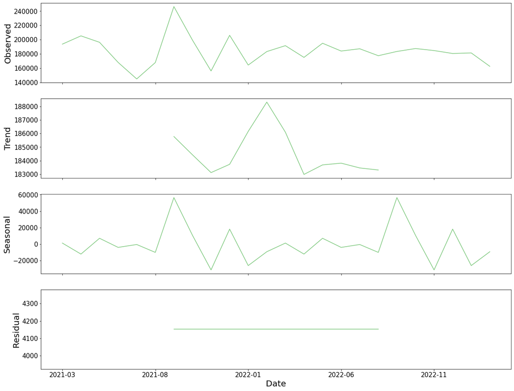

```python
# Analyse de la tendance et la saisonalité du CA pour la catégorie 0 - modalité 'additive'

categ0 = data_propre[data_propre['categ'] == 0.00].groupby(
    data_propre['date'].dt.strftime('%Y-%m'))['price'].sum()
result = seasonal_decompose(categ0, model='additive', period=12)
fig, axes = plt.subplots(4, 1, sharex=True, figsize=(20, 16))
result.observed.plot(ax=axes[0], colormap='Accent', fontsize="15")
axes[0].set_ylabel('Observed', fontsize="20")
result.trend.plot(ax=axes[1], colormap='Accent', fontsize="15")
axes[1].set_ylabel('Trend', fontsize="20")
result.seasonal.plot(ax=axes[2], colormap='Accent', fontsize="15")
axes[2].set_ylabel('Seasonal', fontsize="20")
result.resid.plot(ax=axes[3], colormap='Accent', fontsize="15")
axes[3].set_ylabel('Residual', fontsize="20")
plt.xlabel('Date', fontsize="20")
plt.show()
```

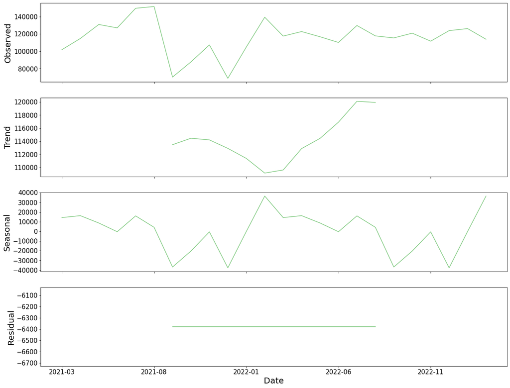

```python
# Analyse de la tendance et la saisonalité du CA pour la catégorie 2 - modalité 'additive'

categ2 = data_propre[data_propre['categ'] == 2.00].groupby(
    data_propre['date'].dt.strftime('%Y-%m'))['price'].sum()
result = seasonal_decompose(categ2, model='additive', period=12)
fig, axes = plt.subplots(4, 1, sharex=True, figsize=(20, 16))
result.observed.plot(ax=axes[0], colormap='Accent', fontsize="15")
axes[0].set_ylabel('Observed', fontsize="20")
result.trend.plot(ax=axes[1], colormap='Accent', fontsize="15")
axes[1].set_ylabel('Trend', fontsize="20")
result.seasonal.plot(ax=axes[2], colormap='Accent', fontsize="15")
axes[2].set_ylabel('Seasonal', fontsize="20")
result.resid.plot(ax=axes[3], colormap='Accent', fontsize="15")
axes[3].set_ylabel('Residual', fontsize="20")
plt.xlabel('Date', fontsize="20")
plt.show()
```

## Zoom sur les références

Les produits qui apportent le plus du CA sont de la catégorie 2, même si les produits mieux vendus sont de la catégorie 1. Cependant, les produits qui amènent le moins du CA et qui sont le moins populaires sont de la catégorie 0.

### Top 10

```python
# Top 10 en terms de CA, plupart entre eux sont de la catégorie 2

data_propre.groupby('id_prod')['price'].sum().agg(
    {'price': {lambda x: x.nlargest(10)}})
```

|  | id_prod | <lambda> |
| --- | --- | --- |
| price | 2_159 | 94893.50 |
|  | 2_135 | 69334.95 |
|  | 2_112 | 65407.76 |
|  | 2_102 | 60736.78 |
|  | 2_209 | 56971.86 |
|  | 1_395 | 54356.25 |
|  | 1_369 | 54025.48 |
|  | 2_110 | 53846.25 |
|  | 2_39 | 53060.85 |
|  | 2_166 | 52449.12 |

```python
# Top 10 en terms de quantité vendue
# Ce qui est différent par rapport au top 10 en terms de CA, c'est qu'ils sont tous de la catégorie 1

data_propre.groupby('id_prod')['session_id'].count().agg(
    {'session_id': {lambda x: x.nlargest(10)}})
```

|  | id_prod | <lambda> |
| --- | --- | --- |
| session_id | 1_369 | 2252 |
|  | 1_417 | 2189 |
|  | 1_414 | 2180 |
|  | 1_498 | 2128 |
|  | 1_425 | 2096 |
|  | 1_403 | 1960 |
|  | 1_412 | 1951 |
|  | 1_413 | 1945 |
|  | 1_406 | 1939 |
|  | 1_407 | 1935 |

### Flop 20

```python
# Flop 20 en terms de CA, ils sont tous de la catégorie 0

data_propre.groupby('id_prod')['price'].sum().agg(
    {'price': {lambda x: x.nsmallest(20)}})
```

|  | id_prod | <lambda> |
| --- | --- | --- |
| price | 0_1539 | 0.99 |
|  | 0_1284 | 1.38 |
|  | 0_1653 | 1.98 |
|  | 0_1601 | 1.99 |
|  | 0_541 | 1.99 |
|  | 0_807 | 1.99 |
|  | 0_1728 | 2.27 |
|  | 0_1498 | 2.48 |
|  | 0_898 | 2.54 |
|  | 0_1840 | 2.56 |
|  | 0_1191 | 2.97 |
|  | 0_1759 | 2.97 |
|  | 0_643 | 2.97 |
|  | 0_1151 | 2.99 |
|  | 0_1379 | 2.99 |
|  | 0_1683 | 2.99 |
|  | 0_549 | 2.99 |
|  | 0_833 | 2.99 |
|  | 0_324 | 3.54 |
|  | 0_902 | 3.68 |

```python
# Flop 20 en terms de quantité vendue, plupart entre eux sont de la catégorie 0

data_propre.groupby('id_prod')['session_id'].count().agg(
    {'session_id': {lambda x: x.nsmallest(20)}})
```

|  | id_prod | <lambda> |
| --- | --- | --- |
| session_id | 0_1151 | 1 |
|  | 0_1284 | 1 |
|  | 0_1379 | 1 |
|  | 0_1498 | 1 |
|  | 0_1539 | 1 |
|  | 0_1601 | 1 |
|  | 0_1633 | 1 |
|  | 0_1683 | 1 |
|  | 0_1728 | 1 |
|  | 0_2201 | 1 |
|  | 0_541 | 1 |
|  | 0_549 | 1 |
|  | 0_807 | 1 |
|  | 0_833 | 1 |
|  | 0_886 | 1 |
|  | 2_23 | 1 |
|  | 2_81 | 1 |
|  | 2_98 | 1 |
|  | 0_1116 | 2 |
|  | 0_1120 | 2 |

## Répartition du CA par client

```python
# Répartition du CA par client, 4 très gros clients détectés
# Peut-être ce sont des clients B to B, peut-être ce sont par exemple les écoles, les Bibliothèques etc.

data_propre.groupby('client_id')['price'].sum().agg(
    {'price': {lambda x: x.nlargest(10)}})
```

|  | client_id | <lambda> |
| --- | --- | --- |
| price | c_1609 | 324033.35 |
|  | c_4958 | 289760.34 |
|  | c_6714 | 153598.92 |
|  | c_3454 | 113637.93 |
|  | c_3263 | 5276.87 |
|  | c_1570 | 5271.62 |
|  | c_2899 | 5214.05 |
|  | c_2140 | 5208.82 |
|  | c_7319 | 5155.77 |
|  | c_7959 | 5085.45 |

```python
# Répartition de la quantité achetée par client
# En terme de quantités que ces 4 clients achetent, sont bien plus gros que les autres

data_propre.groupby('client_id')['session_id'].count().agg(
    {'session_id': {lambda x: x.nlargest(10)}})
```

|  | client_id | <lambda> |
| --- | --- | --- |
| session_id | c_1609 | 25488 |
|  | c_6714 | 9181 |
|  | c_3454 | 6770 |
|  | c_4958 | 5195 |
|  | c_3263 | 403 |
|  | c_2140 | 402 |
|  | c_2595 | 398 |
|  | c_2077 | 384 |
|  | c_1637 | 380 |
|  | c_7421 | 379 |

### Informations sur la typologie des clients

```python
# Dataframe B to B
# Les 4 clients sont extrêmement gros, je les considère comme les grossistes

vente_toB = data_propre[(data_propre['client_id'] == 'c_1609') | (data_propre['client_id'] == 'c_4958') | (
    data_propre['client_id'] == 'c_6714') | (data_propre['client_id'] == 'c_3454')]
vente_toB
```

|  | id_prod | date | session_id | client_id | sex | birth | price | categ |
| --- | --- | --- | --- | --- | --- | --- | --- | --- |
| 2 | 0_1277 | 2022-06-18 15:44:33.155329 | s_225667 | c_6714 | f | 1968 | 7.99 | 0.00 |
| 17 | 1_661 | 2022-09-13 10:18:02.746197 | s_267366 | c_6714 | f | 1968 | 22.99 | 1.00 |
| 32 | 1_426 | 2021-06-21 17:47:57.023863 | s_51846 | c_4958 | m | 1999 | 19.44 | 1.00 |
| 63 | 1_506 | 2021-09-29 03:52:29.731798 | s_97203 | c_4958 | m | 1999 | 13.65 | 1.00 |
| 67 | 0_1446 | 2022-10-05 07:43:00.225116 | s_278030 | c_1609 | m | 1980 | 8.09 | 0.00 |
| ... | ... | ... | ... | ... | ... | ... | ... | ... |
| 679008 | 0_1419 | 2021-04-02 13:23:57.034357 | s_14951 | c_1609 | m | 1980 | 8.99 | 0.00 |
| 679032 | 2_185 | 2021-03-08 01:39:03.755607 | s_3255 | c_4958 | m | 1999 | 43.99 | 2.00 |
| 679069 | 0_1609 | 2021-10-15 16:58:58.818380 | s_105230 | c_6714 | f | 1968 | 18.99 | 0.00 |
| 679081 | 0_1442 | 2022-07-24 00:48:15.130619 | s_242786 | c_6714 | f | 1968 | 4.89 | 0.00 |
| 679093 | 0_1160 | 2021-11-09 21:41:41.807534 | s_117240 | c_1609 | m | 1980 | 17.87 | 0.00 |

46634 rows × 8 columns

```python
# Dataframe B to C

vente_toC = data_propre.drop(vente_toB.index).reset_index(drop=True)
vente_toC
```

|  | id_prod | date | session_id | client_id | sex | birth | price | categ |
| --- | --- | --- | --- | --- | --- | --- | --- | --- |
| 0 | 0_1518 | 2022-05-20 13:21:29.043970 | s_211425 | c_103 | f | 1986 | 4.18 | 0.00 |
| 1 | 1_251 | 2022-02-02 07:55:19.149409 | s_158752 | c_8534 | m | 1988 | 15.99 | 1.00 |
| 2 | 2_209 | 2021-06-24 04:19:29.835891 | s_52962 | c_6941 | m | 2000 | 69.99 | 2.00 |
| 3 | 0_1509 | 2023-01-11 08:22:08.194479 | s_325227 | c_4232 | m | 1980 | 4.99 | 0.00 |
| 4 | 0_1418 | 2022-10-20 15:59:16.084030 | s_285425 | c_1478 | f | 1972 | 8.57 | 0.00 |
| ... | ... | ... | ... | ... | ... | ... | ... | ... |
| 632472 | 0_1551 | 2022-01-15 13:05:06.246925 | s_150195 | c_8489 | f | 1951 | 12.99 | 0.00 |
| 632473 | 1_639 | 2022-03-19 16:03:23.429229 | s_181434 | c_4370 | f | 1977 | 10.99 | 1.00 |
| 632474 | 0_1425 | 2022-12-20 04:33:37.584749 | s_314704 | c_304 | f | 1988 | 12.99 | 0.00 |
| 632475 | 0_1994 | 2021-07-16 20:36:35.350579 | s_63204 | c_2227 | m | 1986 | 4.98 | 0.00 |
| 632476 | 1_523 | 2022-09-28 01:12:01.973763 | s_274568 | c_3873 | m | 1995 | 23.99 | 1.00 |

632477 rows × 8 columns

### Courbe de Lorenz

```python
# Répartition du CA par client pour les ventes B to C

CA_par_client = vente_toC.groupby('client_id').agg({'price': 'sum'}).sort_values(
    'price', ascending=False).reset_index()
CA_par_client
```

|  | client_id | price |
| --- | --- | --- |
| 0 | c_3263 | 5276.87 |
| 1 | c_1570 | 5271.62 |
| 2 | c_2899 | 5214.05 |
| 3 | c_2140 | 5208.82 |
| 4 | c_7319 | 5155.77 |
| ... | ... | ... |
| 8591 | c_4648 | 11.20 |
| 8592 | c_240 | 11.06 |
| 8593 | c_8114 | 9.98 |
| 8594 | c_8140 | 8.30 |
| 8595 | c_8351 | 6.31 |

8596 rows × 2 columns

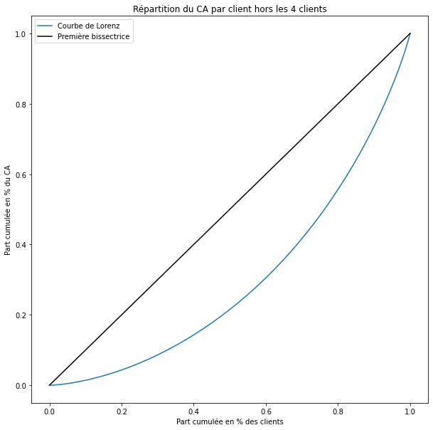

```python
# Courbe de Lorenz sans les 4 gros clients
# La répartition du CA par client n'est pas égalité, il y a des clients achètent plus, autres achètent moins

variable = CA_par_client['price'].values
lorenz = np.cumsum(np.sort(variable)) / variable.sum()
lorenz = np.append([0],lorenz)
fig, ax = plt.subplots(figsize=[10, 10])
ax.plot(np.arange(lorenz.size)/(lorenz.size-1), lorenz, label = 'Courbe de Lorenz')
ax.plot([0, 1], [0, 1], color='k', label = 'Première bissectrice')
plt.xlabel('Part cumulée en % des clients')
plt.ylabel('Part cumulée en % du CA')
plt.title('Répartition du CA par client hors les 4 clients')
plt.legend(loc='upper left')
plt.show()
```

```python
# Calcul de l'indice de Gini

AUC = (lorenz.sum() -lorenz[-1]/2 -lorenz[0]/2)/lorenz.size
S = 0.5 - AUC
gini = 2*S
gini
```

```
0.40268635288994115
```

## Répartition du CA et la quantité vendue par sexe

En regardant tous les clients, la répartition du CA et la quantité vendue entre sexe ne présente pas de grande différence, mais on calcul sans compter les 4 gros clients, les femmes achètent plus que les hommes.

```python
# Répartition du CA et la quantité vendue par sexe
# il n'y a pas de grande différence entre sexe en terms du nombre total d'achats et la somme total d'achats

data_propre.groupby('sex')['price'].agg(['count','sum'])
```

| sex | count | sum |
| --- | --- | --- |
| f | 338285 | 5859683.13 |
| m | 340826 | 5994045.55 |

```python
# Répartition du CA et la quantité vendue par sex sans compter les 4 gros clients
# Les femmes achètent plus que les hommes

vente_toC.groupby('sex')['price'].agg(['count','sum'])
```

| sex | count | sum |
| --- | --- | --- |
| f | 329104 | 5706084.21 |
| m | 303373 | 5266613.93 |

## Calcul de la probabilité pour vérifier la relation entre deux ouvrages

D'après le calcul, un client achète l'ouvrage de la référence 2_159, il a 86% de chance d'acheter l'ouvrage de la référence 0_525.

```python
# Calcul de la probabilité d’un client achète la référence 0_525 sachant qu’il a acheté la référence 2_159
# Sans compter les 4 gros clients

V1 = vente_toC.loc[vente_toC['id_prod'] == '0_525', 'client_id']
V2 = vente_toC.loc[vente_toC['id_prod'] == '2_159', 'client_id']
V3 = vente_toC['client_id'].nunique()
V = pd.Series(list(set(V1).intersection(set(V2))))
P = '{:.2%}'.format((len(V)/V3)/(V2.nunique()/V3))
P
```

```
'86.50%'
```

```python
# Calcul de la probabilité d’un client achète la référence 0_525 sachant qu’il a acheté la référence 2_159
# Inclure les 4 gros clients

V4 = data_propre.loc[data_propre['id_prod'] == '0_525', 'client_id']
V5 = data_propre.loc[data_propre['id_prod'] == '2_159', 'client_id']
V6 = data_propre['client_id'].nunique()
V0 = pd.Series(list(set(V4).intersection(set(V5))))
P1 = '{:.2%}'.format((len(V0)/V6)/(V5.nunique()/V6))
P1
```

```
'86.60%'
```

# Vérification et analyse de la corrélation entre différents variables

## Création de nouvelle colonne - âge

```python
# Création d'une nouvelle colonne âge

vente_toC['age'] = 2023 - vente_toC['birth']
vente_toC
```

|  | id_prod | date | session_id | client_id | sex | birth | price | categ | age |
| --- | --- | --- | --- | --- | --- | --- | --- | --- | --- |
| 0 | 0_1518 | 2022-05-20 13:21:29.043970 | s_211425 | c_103 | f | 1986 | 4.18 | 0.00 | 37 |
| 1 | 1_251 | 2022-02-02 07:55:19.149409 | s_158752 | c_8534 | m | 1988 | 15.99 | 1.00 | 35 |
| 2 | 2_209 | 2021-06-24 04:19:29.835891 | s_52962 | c_6941 | m | 2000 | 69.99 | 2.00 | 23 |
| 3 | 0_1509 | 2023-01-11 08:22:08.194479 | s_325227 | c_4232 | m | 1980 | 4.99 | 0.00 | 43 |
| 4 | 0_1418 | 2022-10-20 15:59:16.084030 | s_285425 | c_1478 | f | 1972 | 8.57 | 0.00 | 51 |
| ... | ... | ... | ... | ... | ... | ... | ... | ... | ... |
| 632472 | 0_1551 | 2022-01-15 13:05:06.246925 | s_150195 | c_8489 | f | 1951 | 12.99 | 0.00 | 72 |
| 632473 | 1_639 | 2022-03-19 16:03:23.429229 | s_181434 | c_4370 | f | 1977 | 10.99 | 1.00 | 46 |
| 632474 | 0_1425 | 2022-12-20 04:33:37.584749 | s_314704 | c_304 | f | 1988 | 12.99 | 0.00 | 35 |
| 632475 | 0_1994 | 2021-07-16 20:36:35.350579 | s_63204 | c_2227 | m | 1986 | 4.98 | 0.00 | 37 |
| 632476 | 1_523 | 2022-09-28 01:12:01.973763 | s_274568 | c_3873 | m | 1995 | 23.99 | 1.00 | 28 |

632477 rows × 9 columns

## Lien entre le genre d’un client et les catégories des livres achetés

En regardant les valeurs du tableau de contingence, nous pouvons constater qu'il y a plus de ventes chez les femmes. Nous pouvons, au premier abord, constater qu'il y a une différence de comportement entre les genres.

Cependant, lorsque nous regardons en termes de proportion de chaque catégorie, cette différence de comportement entre les genres semblent minimes voir négligeable et peut potentiellement être attribué à une fluctuation statistique.

La conclusion que je peux tirer selon le test de Khi2 et le heatmap est donc que:

### Création d'une table de contingence

```python
# Création de la table contingence - variables « sex » et « catégorie »

x = 'sex'
y = 'categ'
table = vente_toC[[x, y]].pivot_table(index=x, columns=y,
                                      aggfunc=len, margins=True, margins_name='Total')
table
```

| categ sex | 0.0 | 1.0 | 2.0 | Total |
| --- | --- | --- | --- | --- |
| f | 200793 | 111331 | 16980 | 329104 |
| m | 186488 | 101017 | 15868 | 303373 |
| Total | 387281 | 212348 | 32848 | 632477 |

```python
pd.crosstab(vente_toC['sex'], vente_toC['categ'], normalize='index')
```

| categ sex | 0.00 | 1.00 | 2.00 |
| --- | --- | --- | --- |
| f | 0.61 | 0.34 | 0.05 |
| m | 0.61 | 0.33 | 0.05 |

### Test de Khi2

```python
# Test de Khi2 - variables  « genre des clients » et « catégories des livres achetés »

# H0: le choix d'un produit ne dépend pas de ni la catégorie, ni la sex des clients
# H1: le choix d'un produit dépend soit de la sex des clients, soit de la catégorie
# Test au seuil de 5%
# Rejetons l’hypothèse nulle au seuil de 5%, donc pour une pvaleur 0.002 inférieure à 0.05
# Le choix d'un produit dépend soit de la sex des clients, soit de la catégorie

chi2, pvalue, degrees, expected = stats.chi2_contingency(table)
chi2, degrees, pvalue
```

```
(20.213460693513895, 6, 0.0025371819244419495)
```

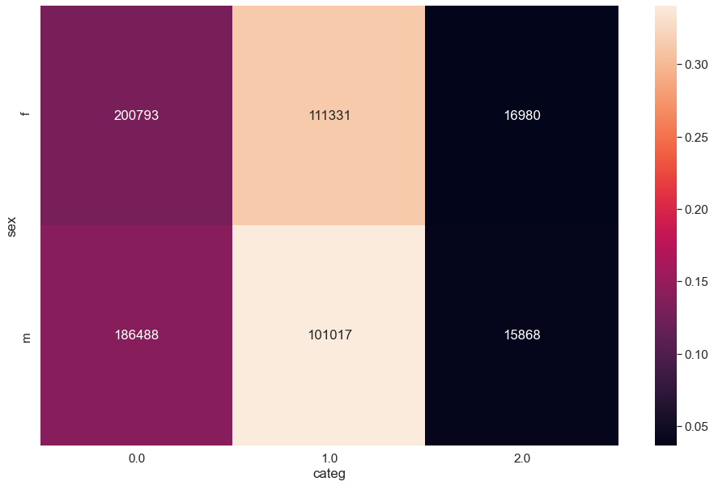

```python
# Pour vérifier la test de Khi2, on va regarder à l'aide de heatmap
# En effet, le choix d'un produit ne dépend pas de la sex des clients, mais dépend de la catégorie des produits

tx = table.loc[:, ["Total"]]
ty = table.loc[["Total"], :]
n = len(vente_toC)
indep = tx.dot(ty) / n

c = table
measure = (c-indep)**2/indep
xi_n = measure.sum().sum()
table1 = measure/xi_n

sns.set(rc={'figure.figsize': (16, 10)},font_scale=1.4)
sns.heatmap(table1.iloc[:-1, :-1], annot=c.iloc[:-1, :-1], fmt="d")
plt.show()
```

## Lien entre l’âge des clients et le montant total des achats

### Calcul du nombre d'achat et du montant total des achats par âge

```python
# Création d'une dataframe pour calculer le nombre d'achat et le montant total des achats par âge

table2 = vente_toC.groupby('age')['price'].agg(
    ['count', 'sum']).sort_values('sum').reset_index()
table2
```

|  | age | count | sum |
| --- | --- | --- | --- |
| 0 | 92 | 170 | 2815.45 |
| 1 | 94 | 201 | 3221.85 |
| 2 | 93 | 226 | 4013.87 |
| 3 | 88 | 271 | 4793.55 |
| 4 | 91 | 311 | 5043.19 |
| ... | ... | ... | ... |
| 71 | 37 | 23465 | 309125.29 |
| 72 | 45 | 24659 | 324490.80 |
| 73 | 35 | 25000 | 330760.73 |
| 74 | 44 | 24878 | 334267.72 |
| 75 | 19 | 15149 | 609013.69 |

76 rows × 3 columns

### Test de Kolmogorov-Smirnov

```python
# Vérification si la variable 'âge' suivre la loi normale

# H0:la variable âge suivre la loi normale
# H1:la variable âge ne suivre pas la loi normale

# P=0.0, inférieur au seuil de 0.05
# Rejetons l’hypothèse nulle au seuil de 5%
# La variable âge ne suivre pas la loi normale
# On doit utiliser les tests non paramétriques

x = vente_toC['age']
resultat = stats.kstest(x, 'norm')
resultat
```

```
KstestResult(statistic=1.0, pvalue=0.0)
```

### Test de Pearson

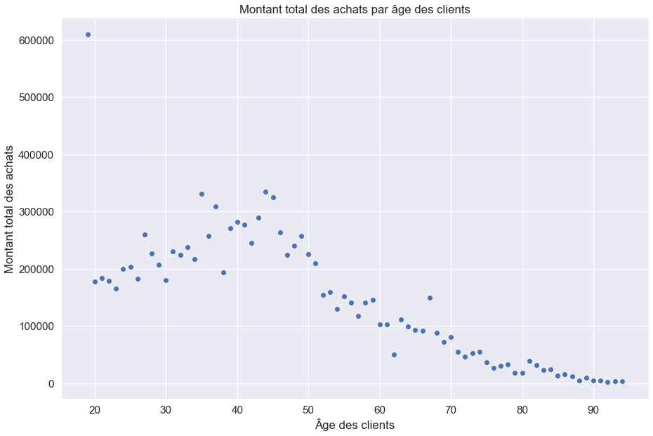

```python
# Montant total des achats par âge des clients

plt.figure(figsize=(15, 10))
plt.scatter(table2['age'],table2['sum'])
plt.ylabel('Montant total des achats')
plt.xlabel('Âge des clients')
plt.title("Montant total des achats par âge des clients")
plt.show()
```

```python
# Test de corrélation Pearson - variables  « âge » et « Montant total des achates »

# Coeffcient = -0.831, proche de -1, forte corrélation négative
# Les variables « âge » et « Montant total des achates » sont fortement corrélées

pearson_coeff, pvalue = stats.pearsonr(table2['age'], table2['sum'])
print('pearson_coeff={:.3f},pvalue={:.20f}'.format(pearson_coeff, pvalue))
```

```
pearson_coeff=-0.831,pvalue=0.00000000000000000002
```

## Lien entre l’âge des clients et la fréquence d’achat

En utilisant le test de Pearson, j’ai le coefficient de -0.574. Ça représente une corrélation négative, mais pas très forte. Quand on regards le graphique, on peut voir que cette corrélation est plutôt concernée les clients à partir de 50 ans. Cependant, on ne voit pas trop la relation pour les clients de moins de 50 ans, moins de 31 ans, la fréquence est autour de 5000 fois par 2 ans à part les clients de 19 ans, entre 31-50, c’est irrégulier.

### Test de Pearson

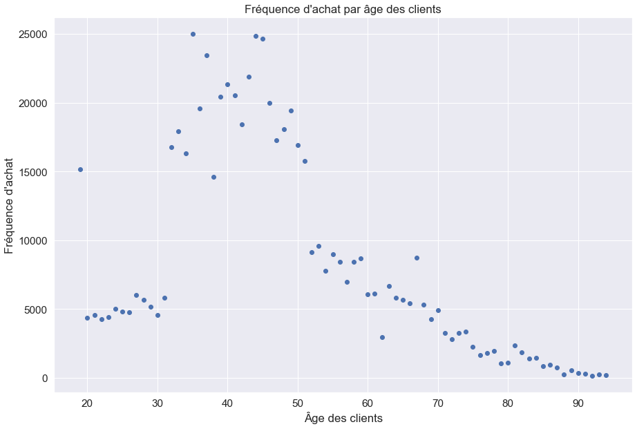

```python
# Fréquence d'achat par âge des clients

plt.figure(figsize=(15, 10))
plt.scatter(table2['age'],table2['count'])
plt.ylabel("Fréquence d'achat")
plt.xlabel('Âge des clients')
plt.title("Fréquence d'achat par âge des clients")
plt.show()
```

```python
# Test de corrélation Pearson - variables  « âge » et « Fréquence d'achate »

# Coeffcient = -0.574, plustôt proche de -1, une corrélation négative pas très forte
# Les variables « âge » et « Fréquence d'achate » sont fortement corrélées

pearson_coeff, pvalue = stats.pearsonr(table2['age'],table2['count'])
print('pearson_coeff={:.3f},pvalue={:.8f}'.format(pearson_coeff, pvalue))
```

```
pearson_coeff=-0.574,pvalue=0.00000006
```

## Lien entre l’âge des clients et la taille du panier moyen

Toujours test de Pearson, le coefficient est de -0.547. Ça représente une corrélation négative, mais pas très forte. On voit sur le graphique, les jeunes moins de 31 ans, ils achètent plus cher, les clients entre 31-50 ans, ils ont une taille du panier moyen le plus basse, même si la fréquence d’achat est élevée, et la taille est plutôt égalité, pareil pour les clients à partir de 50 ans, plus égalité, mais un peu plus élevé.

### Calcul de la taille du panier moyen

```python
# Calcul de la taille du panier moyen

table2['panier_moyen']=table2['sum']/table2['count']
table2.sort_values('panier_moyen')
```

|  | age | count | sum | panier_moyen |
| --- | --- | --- | --- | --- |
| 56 | 47 | 17266 | 224471.58 | 13.00 |
| 63 | 36 | 19604 | 257060.36 | 13.11 |
| 72 | 45 | 24659 | 324490.80 | 13.16 |
| 66 | 46 | 19983 | 263060.92 | 13.16 |
| 71 | 37 | 23465 | 309125.29 | 13.17 |
| ... | ... | ... | ... | ... |
| 75 | 19 | 15149 | 609013.69 | 40.20 |
| 44 | 20 | 4371 | 178195.78 | 40.77 |
| 45 | 22 | 4252 | 178497.70 | 41.98 |
| 51 | 25 | 4840 | 203545.80 | 42.05 |
| 65 | 27 | 6028 | 259425.12 | 43.04 |

76 rows × 4 columns

### Test de Pearson

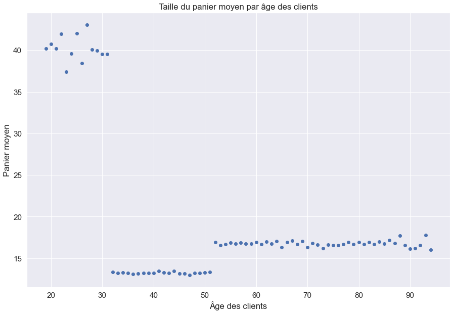

```python
# Taille du panier moyen par âge des clients

plt.figure(figsize=(15, 10))
plt.scatter(table2['age'],table2['panier_moyen'])
plt.ylabel("Panier moyen")
plt.xlabel('Âge des clients')
plt.title("Taille du panier moyen par âge des clients")
plt.show()
```

```python
# Test de corrélation Pearson - variables  « âge » et « Taille du panier moyen »

# Coeffcient = -0.547, plustôt proche de -1, une corrélation négative pas très forte
# Les variables « âge » et « Taille du panier moyen » sont fortement corrélées

pearson_coeff, pvalue = stats.pearsonr(table2['age'],table2['panier_moyen'])
print('pearson_coeff={:.3f},pvalue={:.7f}'.format(pearson_coeff, pvalue))
```

```
pearson_coeff=-0.547,pvalue=0.0000003
```

## Lien entre l’âge des clients et les catégories des livres achetés

Il s’agit d’un lien entre une variable quantitative et une variable qualitative. Je vérifie d’abord si la condition nous permet d’utiliser un test paramétrique ANOVA, finalement, non, la variable âge ne suivre pas la loi normale, les variances pour chaque groupe ne sont pas égales, je dois utiliser un test de Kruskal – Wallis, qui est équivalent du ANOVA, mais non paramétrique. Et j’ai P valeur inférieur à 5%, on rejet l’hypothèse nulle, la répartition de l’âge entre chaque catégorie ne sont pas égale. Les produits de la catégorie 2 sont préférés par les jeunes, les produits de la catégorie 0 et 1 sont plutôt achetés par les gens d’entre 40-50 ans.

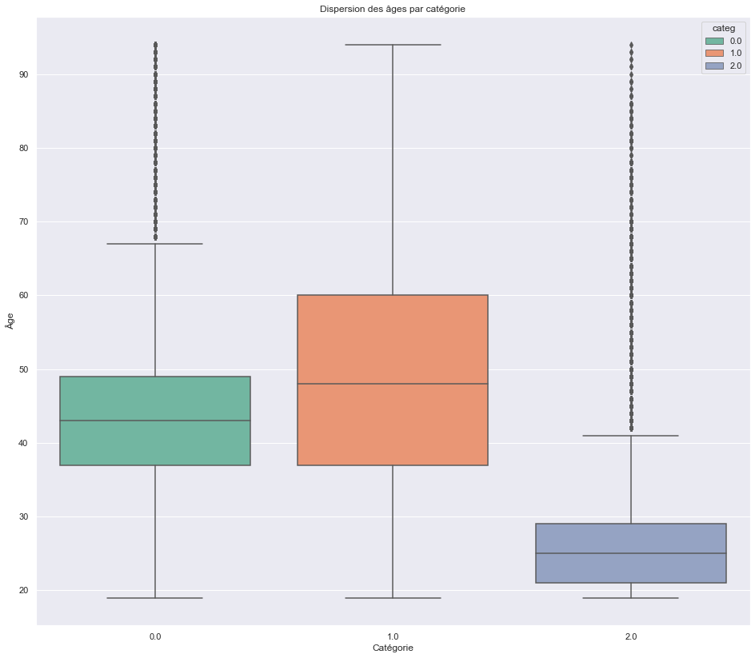

```python
# Dispersion des âges des clients par catégorie

sns.set(rc={'figure.figsize': (16, 14)})
ax = sns.boxplot(y="age", x="categ", data=vente_toC,
                 hue='categ', dodge=False, palette='Set2')
ax.set_title('Dispersion des âges par catégorie')
ax.set_xlabel('Catégorie')
ax.set_ylabel('Âge')
```

### Test de Kolmogorov-Smirnov

```python
# Vérification la normalité de chaque group de la variable 'categ'

# H0:la variable suivre la loi normale
# H1:la variable ne suivre pas la loi normale

# P=0.0, inférieur au seuil de 0.05
# Rejetons l’hypothèse nulle au seuil de 5%
# La variable testée ne suivre pas la loi normale
# On doit utiliser les tests non paramétriques

x1 = vente_toC[vente_toC['categ'] == 0.00]['age']
resultat = stats.kstest(x1, 'norm')
resultat
```

```
KstestResult(statistic=1.0, pvalue=0.0)
```

```python
x2 = vente_toC[vente_toC['categ'] == 1.00]['age']
resultat = stats.kstest(x2, 'norm')
resultat
```

```
KstestResult(statistic=1.0, pvalue=0.0)
```

```python
x3 = vente_toC[vente_toC['categ'] == 2.00]['age']
resultat = stats.kstest(x3, 'norm')
resultat
```

```
KstestResult(statistic=1.0, pvalue=0.0)
```

### Test de Levene

```python
# Vérification l'homogénéité de chaque groupe de la variable 'categ'

# H0:les variances de chaque groupe de la variable 'categ' sont égaux
# H1:les variances de chaque groupe de la variable 'categ' ne sont pas égaux

# P=0.0, inférieur au seuil de 0.05
# Rejetons l’hypothèse nulle au seuil de 5%
# Les variances de chaque groupe de la variable 'categ' ne sont pas égaux
# On doit utiliser les tests non parametriques

x = vente_toC[vente_toC['categ'] == 0.00]['age']
y = vente_toC[vente_toC['categ'] == 1.00]['age']
z = vente_toC[vente_toC['categ'] == 2.00]['age']
stat, p = stats.levene(x, y, z)
print(stat, p)
```

```
23872.531967065435 0.0
```

### Test de Kruskal-Wallis

```python
# Test de Kruskal-Wallis - variables  « âge » et « catégories des livres achetés »

# H0: La répartition des âges des clients dans les trois catégories sont égaux
# H1: La répartition des âges des clients dans les trois catégories ne sont pas égaux
# Test au seuil de 5%
# Rejetons l’hypothèse nulle au seuil de 5%, donc pour une pvaleur < 0.05
# La répartition des âges des clients dans les trois catégories ne sont pas égaux

stats.kruskal(x, y, z)
```

```
KruskalResult(statistic=72209.48289794501, pvalue=0.0)
```

# Conclusion

Pour conclure, nous pouvons à travers ces analyses pour améliorer certains points, par exemple, quand on voit les tops et les flops, on peut encore analyser plus profond pour voir les tops appartient à quels auteurs et quel type de livre (romains, science, cuisine, etc.), on peut attacher de l’importance à ces auteurs ou ce type de livre, et ajuster notre approvisionnement et optimiser nos stocks.

On peut aussi renforcer certains points, par exemple, à travers l’analyse du CA, on peut faire attention à ceux qui nous apportent plus de la valeur ajouter, ou encore, à travers les analyses de la relation entre différentes variables et les comportements des clients, on peut ajuster notre diffusion des publicités, c’est-à-dire selon différent âge des clients et la popularité des livres au sein de chaque groupe d’âge, on fait un pub correspond aux différents clients cibles, selon la fréquence d’achat, on ajuster la fréquence d’envoie de newsletters. Etc. En regardant le lien entre les deux ouvrages, on peut également chercher autre cas comme celui qui nous donne une stratégie de vente regroupé.

On a aussi certains points à éviter, par exemple, on doit éviter la rupture du stock, cela fait abaisser notre CA.